# PCA_vcf

Paco

2025-03-25

# Análisis del fichero VCF obtenido en el pipeline

En este markdown se expone el procesamiento y análisis realizado para extraer información de interés sobre las variantes filtradas. Dado que se proponen realizar técnicas de reducción de la dimensionalidad necesitamos retransformar el vcf y construir un nuevo dataset con las etiquetas de las muestras, el genotipo renombrado(homocigosis alelo referencia= 0, homocigosis recesivo=2, heterocigosis=1 y en caso de no presentarlo lo asignamos como NOT AVIABLE o NA)

## Preprocesamiento del dataset

### Carga del DataSet Y Transformación

Vamos a tener Na por lo que va ser necesario eliminarar aquellas variantes con x valor de Na, por lo que necesitamos un umbral. Esto no supondrá un sesgo dado que una eliminación controlada es beneficiosa y partimos de 59251 variantes.

```r
library(vcfR)
vcf <- read.vcfR("data.vcf")#leemos el fichero VCF con las variantes filtradas tras el variant calling
```

[output not shown]

```r
gt <- extract.gt(vcf, element = "GT", as.numeric = FALSE)#necesitamos conocer el fenotipo para renombar

gt_num <- gt
gt_num[gt == "0/0"] <- 0
gt_num[gt == "0/1" | gt == "1/0"] <- 1
gt_num[gt == "1/1"] <- 2
gt_num[gt == "./." | gt == "."] <- NA  # valores faltantes

# Convertir a numeric matrix
gt_num <- apply(gt_num, 2, as.numeric)  # columnas = muestras
```

[output not shown]

```r
geno_matrix <- t(gt_num)  # cambiamos las muestras por filas
print("Evaluamos presencia de NA")
```

```
## [1] "Evaluamos presencia de NA"
```

```r
print("NA por MUESTRA: ")
```

```
## [1] "NA por MUESTRA: "
```

```r
rowSums(is.na(geno_matrix))   # NA por muestra
```

```
## SRR10568982 SRR10568983 SRR10568984 SRR10568985 SRR10568986 SRR10568987
##         158         139         181         370         372         314
## SRR10568988 SRR10568989 SRR10568990 SRR10568991 SRR10568992 SRR10568993
##         332         118         498         264         787         781
## SRR10568994 SRR10568995 SRR10568996 SRR10568997 SRR10568998 SRR10568999
##         842        8394         332         443         393         245
## SRR10569000 SRR10569001 SRR10569002 SRR10569003 SRR10569004 SRR10569005
##         617         508         238         328        5726         329
## SRR10569006 SRR10569007 SRR10569008 SRR10569009 SRR10569010 SRR10569011
##         550         314         456         607         429         374
## SRR10569012 SRR10569013 SRR10569014 SRR10569015 SRR10569016 SRR10569017
##         346        5776        1866        1334         331         742
## SRR10569018 SRR10569019 SRR10569020 SRR10569021 SRR10569022 SRR10569023
##        1189         585         229         297         429         376
## SRR10569024 SRR10569025 SRR10569026 SRR10569027 SRR10569028 SRR10569029
##         311         296         299         308         164         258
## SRR10569030 SRR10569031 SRR10569032 SRR10569033 SRR10569034 SRR10569035
##         209        2731         246        5511        1261         106
## SRR10569036 SRR10569037 SRR10569038 SRR10569039
##         101         149         309         183
```

```r
print("NA TOTALES")
```

```
## [1] "NA TOTALES"
```

```r
sum(colSums(is.na(geno_matrix)) > 0)
```

```
## [1] 26661
```

### Filtrado de NA

```r
n_muestras <- nrow(geno_matrix)
umbral_na <- 0.052 * n_muestras
geno_filtrado_na <- geno_matrix[, colSums(is.na(geno_matrix)) <= umbral_na]

# Vemos el numero total de columnas con dicho filtro
sum(colSums(is.na(geno_matrix)) > umbral_na)
```

```
## [1] 1893
```

```r
geno_matrix=geno_filtrado_na
```

### Imputación de NA y tratamiento de Variantes con varianza 0.

```r
#calculamos la media por columna y sustituimos el NA por el valor de la medida.
for (i in 1:ncol(geno_matrix)) {
  geno_matrix[is.na(geno_matrix[, i]), i] <- mean(geno_matrix[, i], na.rm = TRUE)
}
print(paste0("na detectados tras imputar: ",sum(is.na(geno_matrix))))
```

```
## [1] "na detectados tras imputar: 0"
```

```r
library(caret)
nzv <- nearZeroVar(geno_matrix, saveMetrics = TRUE)

suma=sum(nzv$nzv)
print(paste("Numero de columnas con varianza proxima a 0:",suma))
```

```
## [1] "Numero de columnas con varianza proxima a 0: 5157"
```

```r
geno_final <- geno_matrix[, !nzv$nzv]

#Finalmente escalamos y centramos los datos
geno_final<-scale(geno_final)
```

Observamos que ya no tenemos Na en nuestro dataset, que se han eliminado un total de 5157 variantes con varianza 0 o cercana a 0 y se han centrado y escalado los datos por lo que ya disponemos de un dataset para realizar reducción de dimensionalidad.

## UMAP

### Análisis csv con subgeneros por muestra

Finalmente con el data set preprocesado se puede cargar el archivo csv que contiene los subgeneros para cada cruce, pero antes podemos evaluar la representación de cada subgenero en el dataset para valorar el balanceo de clases.

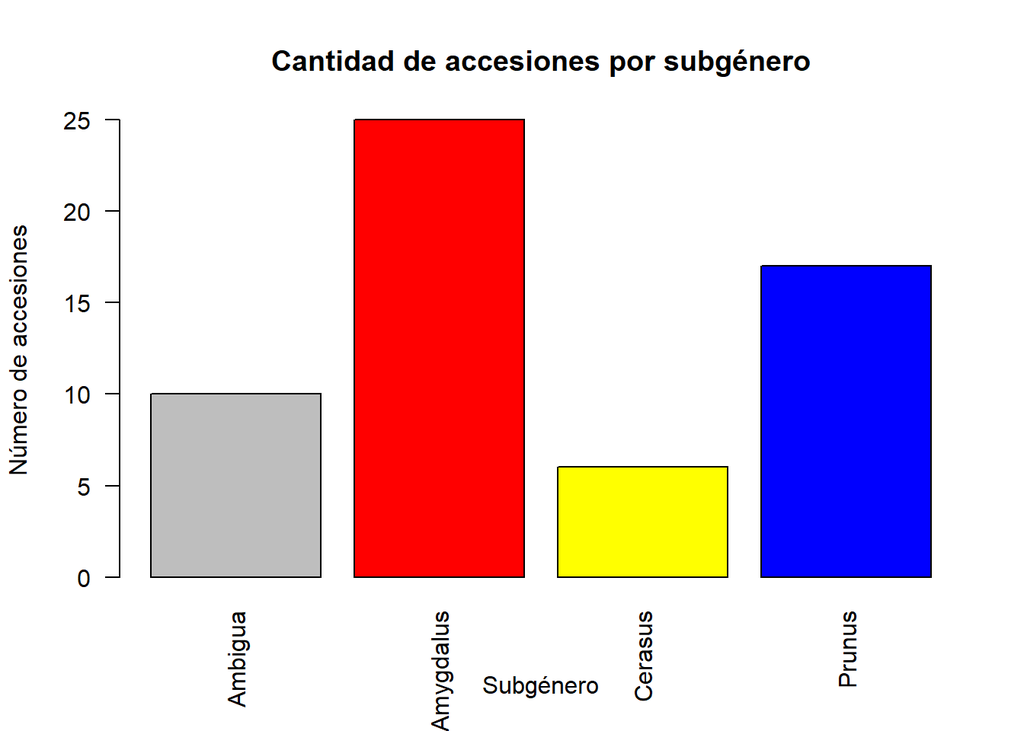

```r
#cargamos un csv que contiene los subgéneros más posibles para cada cruce
subgeneros <- read.csv("Cruces_Prunus_Clasificados.csv")

# Contar accesiones por subgénero
tabla_frecuencias <- table(subgeneros$Subgénero.asignado)

# Definir colores en el mismo orden que aparecen en la tabla
colores_ordenados <- c("Ambigua" = "grey",
                       "Amygdalus" = "red",
                       "Cerasus" = "yellow",
                       "Prunus" = "blue")

# Reordenar colores según el orden de los factores en la tabla
colores_usar <- colores_ordenados[names(tabla_frecuencias)]

# Graficar
barplot(tabla_frecuencias,
        col = colores_usar,
        main = "Cantidad de accesiones por subgénero",
        ylab = "Número de accesiones",
        xlab = "Subgénero",
        las = 2)  # Rotar etiquetas si son largas
```

Como se observa existe un claro desbalance de clases, lo que puede influir en la clusterización visual que genere UMAP.

### Reducción de la dimensionalidad en 2 componentes UMAP

Para obtener los resultados propuestos se realizó una configuración exploratoria manual de los parámetros de UMAP.

Se seleccionó la configuración con n_neighbors = 8 y min_dist = 0.05 como representación final, ya que daba la mejor combinación entre separación de subgéneros, compactación interna de los grupos, y posicionamiento con sentido de los híbridos.

Esta parametrización permitió visualizar la estructura genética sin perder información biológicamente relevante, y fue robusta frente a la variabilidad del número de accesiones por grupo, que tal como comentamos es desbalanceada.

```r
library(umap)
```

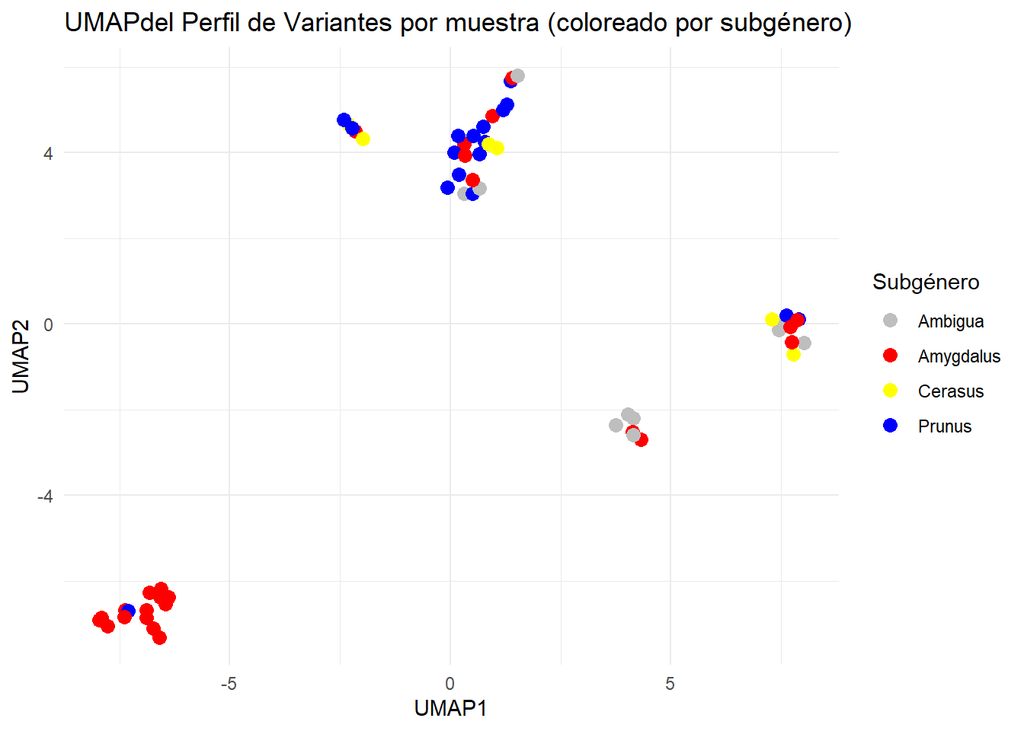

```r
library(ggplot2)

# Leemos csv con información de muestras
cruces <- read.csv("Cruces_Prunus_Clasificados.csv")


# Calcular UMAP
config <- umap.defaults
config$n_neighbors <- 8
config$min_dist <- 0.05
config$metric <- "cosine"
config$random_state <- 42  # semilla de reproducibilidad

# Ejecutar UMAP con esta configuración
umap_result <- umap(geno_final, config = config)

# Crear dataframe con resultados
df_umap <- data.frame(
  Muestra = rownames(geno_final),
  UMAP1 = umap_result$layout[, 1],
  UMAP2 = umap_result$layout[, 2]
)


# Agregar subgénero en un dataframe final donde tendremos las dimensiones de umap por muestra y el subgenero
df_umap <- merge(df_umap, cruces[, c("Run", "Subgénero.asignado")],
                 by.x = "Muestra", by.y = "Run", all.x = TRUE)


# Paleta de colores
subgenero_colores <- c(
  "Amygdalus" = "red",
  "Prunus" = "blue",
  "Cerasus" = "yellow",
  "Ambigua" = "grey"
)

# visualizamos umap
ggplot(df_umap, aes(x = UMAP1, y = UMAP2, color = Subgénero.asignado)) +
  geom_point(size = 3) +
  scale_color_manual(values = subgenero_colores) +
  theme_minimal() +
  labs(title = "UMAPdel Perfil de Variantes por muestra (coloreado por subgénero)",
       color = "Subgénero")
```